# Assignment I – Data Preparation

Mohamed Megahed

3/4/2020

### A Comprehesive Data Exploration and Analysis on CSV and JSON files:

The Open Data 500 is the first comprehensive study of U.S. companies that use open government data to generate new business and develop new products and services. Open Data is free, public data that can be used to launch commercial and nonprofit ventures, conduct research, make data-driven decisions, and solve complex problems

We will analyze two datasets - US_agency.csv and - US_companies.csv.

Loading the dataset :

```r
US_agency <- read_csv("us_agencies.csv")
str(US_agency)
```

```
## Classes 'spec_tbl_df', 'tbl_df', 'tbl' and 'data.frame': 1123 obs. of  11 variables:
##  $ agency_name     : chr  "U.S. House of Representatives" "Arkansas" "Atlanta" "Austin" ...
##  $ agency_abbrev   : chr  NA "AR" "ATL" "AUS" ...
##  $ agency_type     : chr  "Federal Open Data" "State" "City/County" "City/County" ...
##  $ subagency_name  : chr  "General" "General" "General" "General" ...
##  $ subagency_abbrev: chr  NA NA NA NA ...
##  $ url             : chr  NA "http://catalog.data.gov/organization/arkansas-gov" "http://gis.atlantaga.gov/" "http://data.austintexas.gov/" ...
##  $ used_by         : chr  "Civic Impulse LLC" "Pave" "YourMapper" "Code for America" ...
##  $ used_by_category: chr  "Governance" "Finance & Investment" "Geospatial/Mapping" "Governance" ...
##  $ used_by_fte     : chr  "1-10" "1-10" "1-10" "51-200" ...
##  $ dataset_name    : chr  "Upcoming bills in the House" "Post-Completion Wages of Graduates" "Crime" NA ...
##  $ dataset_url     : chr  "http://docs.house.gov/" NA NA NA ...
##  - attr(*, "spec")=
##   .. cols(
##   ..   agency_name = col_character(),
##   ..   agency_abbrev = col_character(),
##   ..   agency_type = col_character(),
##   ..   subagency_name = col_character(),
##   ..   subagency_abbrev = col_character(),
##   ..   url = col_character(),
##   ..   used_by = col_character(),
##   ..   used_by_category = col_character(),
##   ..   used_by_fte = col_character(),
##   ..   dataset_name = col_character(),
##   ..   dataset_url = col_character()
##   .. )
```

```r
US_companies<- read_csv("us_companies.csv")
str(US_companies)
```

```
## Classes 'spec_tbl_df', 'tbl_df', 'tbl' and 'data.frame': 529 obs. of  22 variables:
##  $ company_name_id    : chr  "3-round-stones-inc" "48-factoring-inc" "5psolutions" "abt-associates" ...
##  $ company_name       : chr  "3 Round Stones, Inc." "48 Factoring Inc." "5PSolutions" "Abt Associates" ...
##  $ url                : chr  "http://3RoundStones.com" "https://www.48factoring.com" "www.5psolutions.com" "abtassoc.com" ...
##  $ year_founded       : num  2010 2014 2007 1965 1999 ...
##  $ city               : chr  "Washington" "Philadelphia" "Fairfax" "Cambridge" ...
##  $ state              : chr  "DC" "PA" "VA" "MA" ...
##  $ country            : chr  "us" "us" "us" "us" ...
##  $ zip_code           : chr  "20004" "19087" "22003" "02138" ...
##  $ full_time_employees: chr  "1-10" "51-200" "1-10" "1,001-5,000" ...
##  $ company_type       : chr  "Private" "Private" "Private" "Private" ...
##  $ company_category   : chr  "Data/Technology" "Finance & Investment" "Data/Technology" "Research & Consulting" ...
##  $ revenue_source     : chr  "Data analysis for clients, Database licensing, Subscriptions" "Financial Services" "Subscriptions, User fees for web or mobile access" "Data analysis for clients, Database licensing" ...
##  $ business_model     : chr  "Business to Business, Business to Consumer" "Business to Business" "Business to Business, Business to Consumer, Business to Government" NA ...
##  $ social_impact      : chr  NA "Small Business Owners" NA NA ...
##  $ description        : chr  "3 Round Stones produces a platform for publishing data on the Web. 3 Round Stones provides commercial support f"| __truncated__ "The company mission is to provide finance to small business. We also provide financing to small business with b"| __truncated__ "At 5PSolu…
##  $ description_short  : chr  "Our Open Source platform is used by the Fortune2000 and US Government Agencies to collect, publish and reuse da"| __truncated__ "48 Factoring Inc. is one of the best financial services company using unique factoring 2.0 financial product wh"| __truncated__ "5PSolutio…
##  $ source_count       : chr  NA "11-50" NA "101+" ...
##  $ data_types         : chr  NA "Business" NA NA ...
##  $ example_uses       : chr  NA NA NA NA ...
##  $ data_impacts       : chr  "[]" "[u'Cost efficiency', u'Job growth', u'Revenue growth']" "[]" "[]" ...
##  $ financial_info     : chr  "3 Round Stones is a profitable, self-funded, woman-owned start-up.  Our team has several successful serial entr"| __truncated__ NA NA "Employee-owned company. $552M/year." ...
##  $ last_updated       : POSIXct, format: "2014-11-12 14:44:25" "2015-05-18 11:36:39" ...
##  - attr(*, "spec")=
##   .. cols(
##   ..   company_name_id = col_character(),
##   ..   company_name = col_character(),
##   ..   url = col_character(),
##   ..   year_founded = col_double(),
##   ..   city = col_character(),
##   ..   state = col_character(),
##   ..   country = col_character(),
##   ..   zip_code = col_character(),
##   ..   full_time_employees = col_character(),
##   ..   company_type = col_character(),
##   ..   company_category = col_character(),
##   ..   revenue_source = col_character(),
##   ..   business_model = col_character(),
##   ..   social_impact = col_character(),
##   ..   description = col_character(),
##   ..   description_short = col_character(),
##   ..   source_count = col_character(),
##   ..   data_types = col_character(),
##   ..   example_uses = col_character(),
##   ..   data_impacts = col_character(),
##   ..   financial_info = col_character(),
##   ..   last_updated = col_datetime(format = "")
##   .. )
```

*The load time in reading the dataset using read_csv of tidyverse package is faster compared to read.csv. The main advantage of this function is it parses the file while loading to environment.*

Tasks to explore the dataset and answering the following questions:

**1. Are there any missing columns?**

On a general exploration through data, there is no missing columns. However if the datasets are related, their should be a primary key. There is no primary/unique column in us_agencies dataset which concludes a missing column.

**2. Are there any missing column names or errors in the column names? If so, name those columns.**

```r
colnames(US_agency)
```

```
##  [1] "agency_name"      "agency_abbrev"    "agency_type"      "subagency_name"
##  [5] "subagency_abbrev" "url"              "used_by"          "used_by_category"
##  [9] "used_by_fte"      "dataset_name"     "dataset_url"
```

```r
colnames(US_companies)
```

```
##  [1] "company_name_id"     "company_name"        "url"
##  [4] "year_founded"        "city"                "state"
##  [7] "country"             "zip_code"            "full_time_employees"
## [10] "company_type"        "company_category"    "revenue_source"
## [13] "business_model"      "social_impact"       "description"
## [16] "description_short"   "source_count"        "data_types"
## [19] "example_uses"        "data_impacts"        "financial_info"
## [22] "last_updated"
```

Yes, we have errors in some column names: for the dataset ‘US_agency’

1. “used_by_category” the name of this column should be “category of agency work” or " agency work category" as the agency is not used by category
2. “url” is not clear ftom its name whether it is the agency url or the subagency
3. “used_by”i t is not clear which one is used by the adency or the subagency
4. “used_by_fte” it is not clear from the name what fte represent or what this range is if we assume it is the number of employees in each subagency the name sholud change also cause used_by is inappropriate term here

for the dataset ‘US_companies’

1. “company_name_id” column it just repeats the campany name, so we can use company name column as an id or there should be a numeric id for each company
2. "“data_types”" the names is stating the types of data but the data stored in this variable is about the data ncategory it has so I guess this column is not clear by its name.

**3. Are there any values in the columns missing?** ### First: **US_agency**

Let’s calculate the number and percent of missing data and plot them ** checking if there any missing data using “Amelia package”

```r
# Check if there are any missing values:
anyNA(US_agency)
```

```
## [1] TRUE
```

```r
sum(is.na(US_agency))
```

```
## [1] 2718
```

```r
mean(is.na(US_agency))
```

```
## [1] 0.2200275
```

```r
# the percent of missing data values is 22%

# Checking counts of missing values in columns:
colSums(is.na(US_agency))
```

```
##      agency_name    agency_abbrev      agency_type   subagency_name
##                0              313                0                0
## subagency_abbrev              url          used_by used_by_category
##              709              292                0                4
##      used_by_fte     dataset_name      dataset_url
##               44              548              808
```

### ploting the missing and observed data values

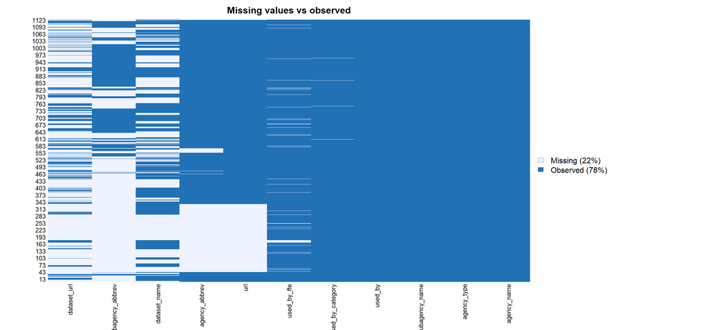

```r
# A visual take on the missing values might be helpful: the Amelia package has a special plotting function missmap() that will plot the dataset and highlight missing values:
library(Amelia)
missmap(US_agency, main = "Missing values vs observed")
```

### Second: **US_companies**

Let’s calculate the number and percent of missing data and plot them ** checking if there any missing data using “Amelia package”

```r
# Check if there are any missing values:
anyNA(US_companies)
```

```
## [1] TRUE
```

```r
sum(is.na(US_companies))
```

```
## [1] 2315
```

```r
mean(is.na(US_companies))
```

```
## [1] 0.1989173
```

```r
# the percent of missing data values is approximately 20%

# Check percentages and counts of missing values in columns:
colSums(is.na(US_companies))
```

```
##     company_name_id        company_name                 url        year_founded
##                   0                   0                   0                   1
##                city               state             country            zip_code
##                  33                   0                   0                  37
## full_time_employees        company_type    company_category      revenue_source
##                  29                  16                   3                  10
##      business_model       social_impact         description   description_short
##                  76                 512                   0                   0
##        source_count          data_types        example_uses        data_impacts
##                 303                 387                 521                   0
##      financial_info        last_updated
##                 387                   0
```

### ploting the missing and observed data values

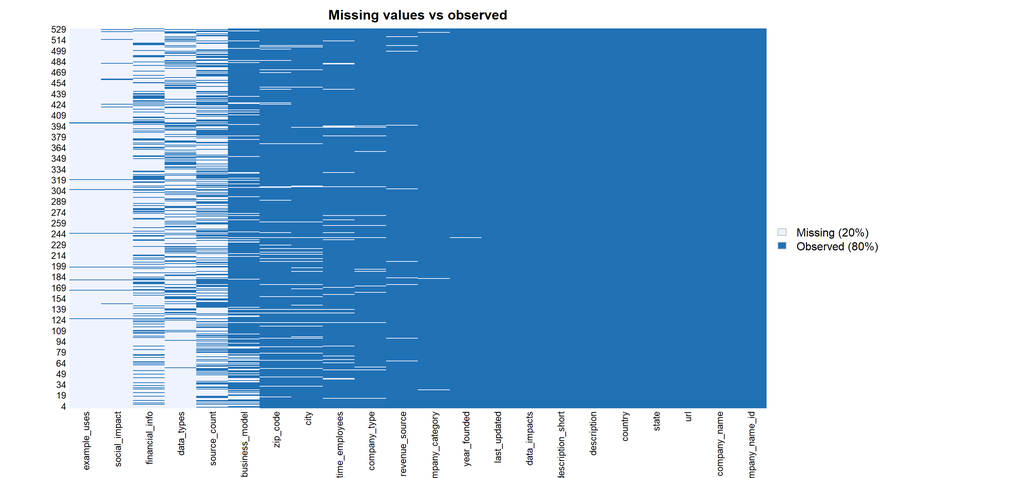

```r
# A visual take on the missing values might be helpful: the Amelia package has a special plotting function missmap() that will plot the dataset and highlight missing values:
library(Amelia)
missmap(US_companies, main = "Missing values vs observed")
```

**YES**, we have missing values in our datasets form the above analysis we can notice the variation in missing data values in each dataset

for **US_Agency** 1. dataset_url 2. subagency_abbrev 3. dataset_name are the columns with highest number of missing values

for **US_Companies** 1. example_uses 2. social_impact 3. financial_info, data_types are the columns with highest number of missing values

**4. How is data organized in each column? Is it properly organized?**

The data is not organized at various columns of the us_agencies and us_companies. Has too many categorical values and has many non-significant columns.

**5. Is data in the proper shape for further analysis? If not, why? Explain.**

Though the data is structured, It still needs to a lot of pre-processing for any analysis. The data is not in proper shape and has a lot of missing values.

- In Us_companies,
  - Column last_updated needs to be parsed.
  - Financial_info column has alot of unwanted tags and characters
  - data_impacts column is not organized and has unreadable characters
  - Coulmns source_count & full_time_employees has values with incorrectly feeded data and needs to be parsed
  - A lot of missing values in columns
- In us_agencies,
  - used_by_fte column needs to be parsed.

**6. How will you fix this dataset? Describe the methods you will use to fix this dataset for further analysis? It can be missing values, NAs, etc. (OPTIONAL: Uploading clean dataset)**

- Any dataset with too many missing values will not give any significant/Actionable insights. But it depends on the importance of the data we have, Usually a safe maximum threshold is 5% missing values, NA’s of the total in each column is followed for further any analysis on the datasets.
- We need to make sure there are no duplicates in the dataset.

```r
#Dataframe without Duplicates
us_ag_noDup<-US_agency %>% distinct()
us_co_noDup<-US_companies %>% distinct()
```

- If missing data for a certain feature or sample is more than 5% then we probably should leave that feature or sample out. We therefore check for features (columns) and samples (rows) where more than 5% of the data is missing using a simple function

```r
#Percentage of missing values at each column
col_miss_per_agency <- colMeans(is.na(US_agency))*100
col_miss_per_agency
```

```
##      agency_name    agency_abbrev      agency_type   subagency_name
##        0.0000000       27.8717720        0.0000000        0.0000000
## subagency_abbrev              url          used_by used_by_category
##       63.1344613       26.0017809        0.0000000        0.3561888
##      used_by_fte     dataset_name      dataset_url
##        3.9180766       48.7978629       71.9501336
```

```r
library(dplyr)
col_miss_per_company <- colMeans(is.na(US_companies))*100
col_miss_per_company
```

```
##     company_name_id        company_name                 url        year_founded
##           0.0000000           0.0000000           0.0000000           0.1890359
##                city               state             country            zip_code
##           6.2381853           0.0000000           0.0000000           6.9943289
## full_time_employees        company_type    company_category      revenue_source
##           5.4820416           3.0245747           0.5671078           1.8903592
##      business_model       social_impact         description   description_short
##          14.3667297          96.7863894           0.0000000           0.0000000
##        source_count          data_types        example_uses        data_impacts
##          57.2778828          73.1568998          98.4877127           0.0000000
##      financial_info        last_updated
##          73.1568998           0.0000000
```

As we can see, there are lot of columns with missing values more than 5%

- There are alot of packages/libraries that deals with the imputation of missing values. One can also follow the conventional ways of imputation without using packages/libraries for numerical variables.
- For mising values, five powerful R packages namely
  - MICE
  - Amelia
  - missForest
  - Hmisc
  - mi

*source: https://www.analyticsvidhya.com/blog/2016/03/tutorial-powerful-packages-imputing-missing-values/*

**7. How are the two datasets linked to each other? Is there a common “primary key” to connect the two datasets?**

As mentioned earlier, There is no Unique row identifier to access the data to perform furtherr analysis using these two datasets.

## Exercise 2:

JSON (JavaScript Object Notation) is a most commonly used data format today and as a data scientist, you must know how to access JSON data sets. JSON is easy for machines to parse and generate. “It is based on a subset of the JavaScript Programming Language Standard ECMA-262 3rd Edition - December 1999. JSON is a text format that is completely language independent [JSON.ORG].”

For this case study, you will parse JSON file, which has city traffic details. “Average Daily Traffic (ADT)” counts are analogous to a census count of vehicles on city streets. These counts provide a close approximation to the actual number of vehicles passing through a given location on an average weekday. Since it is not possible to count every vehicle on every city street, sample counts are taken along larger streets to get an estimate of traffic on half-mile or one-mile street segments. ADT counts are used by city planners, transportation engineers, real-estate developers, marketers and many others for myriad planning and operational purposes. Data Owner: Transportation. Time Period: 2006. Frequency: A citywide count is taken approximately every 10 years. A limited number of traffic counts will be taken and added to the list periodically [https://catalog.data.gov/]"

**1.How many variables are in the dataset?**

```r
# Convert JSON file to a data frame.
ChigoTraffic <- fromJSON("ChicagoTraffic.json")
# prints Total variables
print(nrow(ChigoTraffic$meta$view$columns))
```

```
## [1] 23
```

We have a total of 23 variables in the metadata that concerns with the listed data in json file

**2. Name all the variables?**

```r
# Prints Column names
print(ChigoTraffic$meta$view$columns$name)
```

```
##  [1] "sid"
##  [2] "id"
##  [3] "position"
##  [4] "created_at"
##  [5] "created_meta"
##  [6] "updated_at"
##  [7] "updated_meta"
##  [8] "meta"
##  [9] "ID "
## [10] "Traffic Volume Count Location  Address"
## [11] "Street"
## [12] "Date of Count"
## [13] "Total Passing Vehicle Volume"
## [14] "Vehicle Volume By Each Direction of Traffic"
## [15] "Latitude"
## [16] "Longitude"
## [17] "Location"
## [18] "Boundaries - ZIP Codes"
## [19] "Community Areas"
## [20] "Zip Codes"
## [21] "Census Tracts"
## [22] "Wards"
## [23] ":@computed_region_awaf_s7ux"
```

**3. What is the total traffic of vehicles on 100th street to 115th street?**

```r
# Storing Data values to a variable
CT_data<-ChigoTraffic$data
# The total traffic of vehicles on 100th street to 115th street?
for(i in 1:1279){
  if(CT_data[[i]][[11]] == "100th St"){
    print(as.numeric(CT_data[[i]][[13]]))
  }
  if(CT_data[[i]][[11]] == "101th St"){
    print(as.numeric(CT_data[[i]][[13]]))
  }
  if(CT_data[[i]][[11]] == "102th St"){
    print(as.numeric(CT_data[[i]][[13]]))
  }
  if(CT_data[[i]][[11]] == "103th St"){
    print(as.numeric(CT_data[[i]][[13]]))
    }
  if(CT_data[[i]][[11]] == "104th St"){
    print(as.numeric(CT_data[[i]][[13]]))
    }
  if(CT_data[[i]][[11]] == "105th St"){
    print(as.numeric(CT_data[[i]][[13]]))
    }
  if(CT_data[[i]][[11]] == "106th St"){
    print(as.numeric(CT_data[[i]][[13]]))
    }
   if(CT_data[[i]][[11]] == "107th St"){
    print(as.numeric(CT_data[[i]][[13]]))
    }
  if(CT_data[[i]][[11]] == "108th St"){
    print(as.numeric(CT_data[[i]][[13]]))
    }
  if(CT_data[[i]][[11]] == "109th St"){
    print(as.numeric(CT_data[[i]][[13]]))
    }
  if(CT_data[[i]][[11]] == "110th St"){
    print(as.numeric(CT_data[[i]][[13]]))
    }
  if(CT_data[[i]][[11]] == "111th St"){
    print(as.numeric(CT_data[[i]][[13]]))
    }
  if(CT_data[[i]][[11]] == "112th St"){
    print(as.numeric(CT_data[[i]][[13]]))
    }
  if(CT_data[[i]][[11]] == "113th St"){
    print(as.numeric(CT_data[[i]][[13]]))
    }
  if(CT_data[[i]][[11]] == "114th St"){
    print(as.numeric(CT_data[[i]][[13]]))
    }
  if(CT_data[[i]][[11]] == "115th St"){
    print(as.numeric(CT_data[[i]][[13]]))
    }
}
```

```
## [1] 8200
## [1] 22600
## [1] 8000
## [1] 6300
## [1] 9100
## [1] 11000
## [1] 12800
## [1] 11700
## [1] 15500
## [1] 7900
## [1] 12600
## [1] 12200
## [1] 16500
## [1] 10900
## [1] 16500
## [1] 19800
## [1] 6300
## [1] 800
## [1] 12200
## [1] 20200
## [1] 29800
## [1] 7700
## [1] 12800
```

**4. What is the total traffic of vehicles on geolocations, (41.651861, -87.54501) and (41.66836, -87.620176)**

```r
for(j in 1:1279){
  if(CT_data[[j]][[15]]=="41.651861" && CT_data[[j]][[16]]== "-87.54501"){t1<-as.numeric(CT_data[[j]][[13]])}
  if(CT_data[[j]][[15]]=="41.66836" && CT_data[[j]][[16]]== "-87.620176"){t2<-as.numeric(CT_data[[j]][[13]])}
}
Total_Traffic=t1+t2
print(Total_Traffic)
```

```
## [1] 13600
```

The Total traffic on the given geolocations is 13600.